# Figures 3A and S4B

Paired bagging Random Forest for NanoString biomarker identification (Figure S4B); ROC curves with 95% CI (Figure 3A)

# 1 Introduction

Figure S4B: paired bagging Random Forest to identify NanoString genes that distinguish pre-treatment (W0) from on-treatment (W16) samples in patients with successful treatment outcome (n = 33). Approximately 800 genes were measured at W0 and W16 only. For each bootstrap iteration, patients are sampled with replacement and both visits are included, preserving the paired structure. Importance scores are averaged across all valid iterations.

Figure 3A: ROC curves with 95% bootstrap confidence intervals for the top genes identified by the Random Forest.

# 2 Load packages

```r
library(readxl)
library(DataExplorer)
library(dplyr)
library(tidyr)
library(ggplot2)
library(randomForest)
library(caret)
library(pROC)
library(writexl)
```

# 3 Define file paths

```r
input_file       <- "Input/Nanostring_Wide_log2_normalised.xlsx"
output_fig3a_s4b <- "Output/03. Figure_3A_S4B"

dir.create(output_fig3a_s4b, recursive = TRUE, showWarnings = FALSE)
```

# 4 Load data

```r
all_data <- read_excel(input_file, sheet = 1)

head(all_data)
```

```
# A tibble: 6 × 843
  Barcode   Donor Visit Stimulation Comments   ACE ACKR2 ACKR3 ACKR4 ACOX1 ACSL1
  <chr>     <chr> <chr> <chr>       <chr>    <dbl> <dbl> <dbl> <dbl> <dbl> <dbl>
1 04082179… 31    0     TB          success      0     0     0  0     7.65  13.0
2 04082180… 34    0     NULL        success      0     0     0  0     8.80  12.4
3 04082180… 54    16    TB          success      0     0     0  0     8.30  11.4
4 04082302… 19    0     NULL        success      0     0     0  2.35 10.8   14.0
5 04082302… 23    16    TB          success      0     0     0  1.19  9.01  11.8
6 04082303… 25    0     NULL        treatme…     0     0     0  4.21  9.10  12.9
# ℹ 832 more variables: ACSL3 <dbl>, ACSL4 <dbl>, ACTA2 <dbl>, ACVR1 <dbl>,
#   ADAR <dbl>, ADGRE5 <dbl>, ADGRG3 <dbl>, ADORA2A <dbl>, AGT <dbl>,
#   AHR <dbl>, AIF1 <dbl>, AIM2 <dbl>, AKT1 <dbl>, AKT2 <dbl>, AKT3 <dbl>,
#   ALDH1A1 <dbl>, ALOX12 <dbl>, ALOX15 <dbl>, ALOX5 <dbl>, ALOX5AP <dbl>,
#   ALPK1 <dbl>, ALPL <dbl>, ANKRD22 <dbl>, ANPEP <dbl>, AP1G1 <dbl>,
#   AP1M1 <dbl>, AP1S2 <dbl>, APBB1IP <dbl>, APEX1 <dbl>, APOBEC3G <dbl>,
#   APOL1 <dbl>, APOL6 <dbl>, APP <dbl>, ARRB2 <dbl>, ATF2 <dbl>, ATF4 <dbl>, …
```

```r
dim(all_data)
```

```
[1] 286 843
```

# 5 Filter and recode

One barcode (0408230288) is excluded as a quality control outlier. Stimulation labels are standardised to match the protein data naming convention.

```r
nano_data <- all_data %>%
  filter(Comments == "success") %>%
  mutate(
    Stimulation = ifelse(Stimulation == "TB",   "Mtb_Ag", Stimulation),
    Stimulation = ifelse(Stimulation == "NULL", "Null",   Stimulation),
    Visit       = paste0("W", Visit)
  ) %>%
  filter(!Barcode %in% "0408230288") %>%
  select(-Barcode)

cat(sprintf("Rows: %d | Columns: %d\n", nrow(nano_data), ncol(nano_data)))
```

```
Rows: 231 | Columns: 842
```

```r
cat(sprintf("Visits: %s\n",       paste(unique(nano_data$Visit),       collapse = ", ")))
```

```
Visits: W0, W16
```

```r
cat(sprintf("Stimulations: %s\n", paste(unique(nano_data$Stimulation), collapse = ", ")))
```

```
Stimulations: Mtb_Ag, Null, IL1B, LPS
```

# 6 Data overview

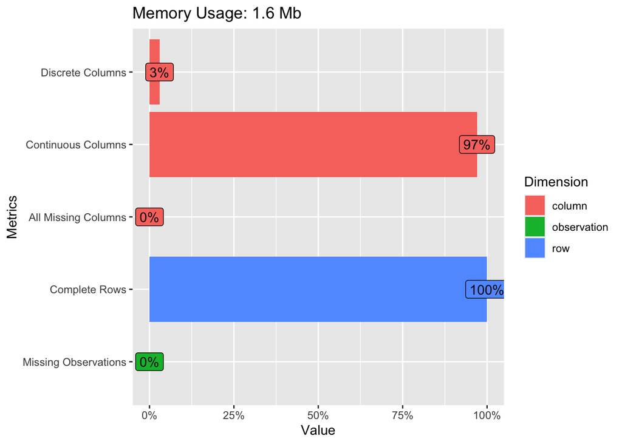

```r
plot_intro(nano_data)
```

# 7 Variance filter at gene level

```r
meta_cols  <- names(nano_data)[1:4]
gene_cols  <- names(nano_data)[5:819]

variances      <- sapply(nano_data[, gene_cols], var, na.rm = TRUE)
retained_genes <- names(variances[variances > 0.1])

nano_data <- nano_data[, c(meta_cols, retained_genes)]

cat(sprintf(
  "Genes before filtering: %d | After filtering: %d\n",
  length(gene_cols), length(retained_genes)
))
```

```
Genes before filtering: 815 | After filtering: 739
```

# 8 Average technical replicates and reshape to wide format

```r
nano_long <- nano_data %>%
  pivot_longer(
    cols      = all_of(retained_genes),
    names_to  = "Gene",
    values_to = "Count_log2"
  )

duplicates <- nano_long %>%
  group_by(Donor, Visit, Comments, Stimulation, Gene) %>%
  summarise(n = n(), .groups = "drop") %>%
  filter(n > 1)

cat(sprintf("Duplicate rows found: %d\n", nrow(duplicates)))
```

```
Duplicate rows found: 0
```

```r
nano_log_wide <- nano_long %>%
  mutate(combined_name = paste(Stimulation, Gene, sep = "_")) %>%
  group_by(Donor, Visit, Comments, combined_name) %>%
  summarise(Count_log2 = mean(Count_log2, na.rm = TRUE), .groups = "drop") %>%
  pivot_wider(
    names_from  = combined_name,
    values_from = Count_log2
  )

cat(sprintf("Wide format: %d rows | %d columns\n", nrow(nano_log_wide), ncol(nano_log_wide)))
```

```
Wide format: 59 rows | 2959 columns
```

# 9 Clean column names

Gene names can contain special characters that are invalid as R variable names. A lookup table maps original names to cleaned names for reference.

```r
original_names <- names(nano_log_wide)
cleaned_names  <- make.names(original_names, unique = TRUE)

name_map <- data.frame(
  original = original_names,
  cleaned  = cleaned_names,
  stringsAsFactors = FALSE
)

names(nano_log_wide) <- cleaned_names

renamed <- name_map %>% filter(original != cleaned)
cat(sprintf("Columns renamed due to special characters: %d\n", nrow(renamed)))
```

```
Columns renamed due to special characters: 100
```

# 10 Check for missing values

```r
feature_cols_wide <- setdiff(names(nano_log_wide), c("Donor", "Visit", "Comments"))
na_counts         <- colSums(is.na(nano_log_wide[, feature_cols_wide]))

cat(sprintf(
  "Columns with NAs: %d | Total NAs: %d | Missing rate: %.2f%%\n",
  sum(na_counts > 0),
  sum(na_counts),
  100 * sum(na_counts) / (nrow(nano_log_wide) * length(feature_cols_wide))
))
```

```
Columns with NAs: 2956 | Total NAs: 3695 | Missing rate: 2.12%
```

```r
nano_log_wide <- nano_log_wide[complete.cases(nano_log_wide), ]
cat(sprintf("Complete rows retained: %d\n", nrow(nano_log_wide)))
```

```
Complete rows retained: 54
```

# 11 Hyperparameter configuration

```r
rf_config <- list(
  W0_W16 = list(
    patient_id_col     = "Donor",
    visits             = c("W0", "W16"),
    variance_threshold = 0.01,
    n_random           = 10,
    n_bags             = 100,
    ntree              = 600,
    n_bootstrap_roc    = 500,
    top_n_genes        = 4
  )
)
```

# 12 Helper functions

`prepare_rf_data`: filters to the visit pair, converts Visit to a valid factor, removes low-variance features, and adds random reference features. The Comments column is excluded because it is outcome-related metadata, not a predictor.

```r
prepare_rf_data <- function(wide_data, config) {
  visits             <- config$visits
  variance_threshold <- config$variance_threshold
  n_random           <- config$n_random
  patient_id_col     <- config$patient_id_col

  data_filt <- wide_data %>%
    filter(Visit %in% visits) %>%
    mutate(Visit = factor(Visit, levels = visits))

  levels(data_filt$Visit) <- paste0("W", gsub("W", "", levels(data_filt$Visit)))

  non_feature  <- c(patient_id_col, "Visit", "Comments")
  feature_cols <- setdiff(names(data_filt), non_feature)
  variances    <- sapply(data_filt[, feature_cols], var, na.rm = TRUE)
  retained     <- names(variances[variances > variance_threshold])
  data_filt    <- data_filt[, c(patient_id_col, "Visit", retained)]

  gene_vals <- unlist(data_filt[, retained], use.names = FALSE)
  rand_mean <- mean(gene_vals, na.rm = TRUE)
  rand_sd   <- sd(gene_vals,   na.rm = TRUE)

  set.seed(123)
  random_cols <- paste0("Random_", seq_len(n_random))
  for (col in random_cols) {
    data_filt[[col]] <- rnorm(nrow(data_filt), mean = rand_mean, sd = rand_sd)
  }

  cat(sprintf(
    "Visits: %s | Rows: %d | Features retained: %d | Random added: %d\n",
    paste(visits, collapse = " vs "), nrow(data_filt),
    length(retained), n_random
  ))

  list(data = data_filt, retained = retained, random_cols = random_cols)
}
```

`tune_rf`: tunes `mtry` using patient-level grouped k-fold CV. All patients are in the CV pool since there is no held-out test set.

```r
tune_rf <- function(prep, config) {
  data           <- prep$data
  k_folds        <- config$k_folds
  ntree          <- config$ntree
  mtry_range     <- config$mtry_range
  patient_id_col <- config$patient_id_col

  patient_ids <- data[[patient_id_col]]
  data_train  <- data[, !names(data) %in% patient_id_col]
  n_pred      <- ncol(data_train) - 1

  if (is.null(mtry_range)) {
    mtry_range <- seq(2, floor(sqrt(n_pred)), by = 1)
  }

  set.seed(123)
  group_folds <- groupKFold(patient_ids, k = k_folds)

  train_f1 <- unique(patient_ids[group_folds[[1]]])
  test_f1  <- unique(patient_ids)[!unique(patient_ids) %in% train_f1]
  cat(sprintf(
    "Fold 1 leakage check - Train: %d | Test: %d | Overlap: %d\n",
    length(train_f1), length(test_f1),
    length(intersect(train_f1, test_f1))
  ))

  ctrl <- trainControl(
    method          = "cv",
    index           = group_folds,
    classProbs      = TRUE,
    savePredictions = "final",
    summaryFunction = twoClassSummary,
    verboseIter     = FALSE
  )

  set.seed(123)
  tuned <- tryCatch(
    train(
      Visit ~ .,
      data       = data_train,
      method     = "rf",
      trControl  = ctrl,
      tuneGrid   = expand.grid(mtry = mtry_range),
      ntree      = ntree,
      metric     = "ROC",
      importance = TRUE
    ),
    error = function(e) { message("Tuning failed: ", e$message); NULL }
  )

  if (is.null(tuned)) stop("RF tuning failed.")

  best_mtry <- tuned$bestTune$mtry
  cat(sprintf("Best mtry: %d\n", best_mtry))
  print(tuned)

  best_mtry
}
```

`bag_rf`: paired patient-level bootstrap RF. For each iteration, patients are sampled with replacement and both visits are included. Importance scores are averaged and SD computed across all valid iterations.

```r
bag_rf <- function(prep, best_mtry, config) {
  data           <- prep$data
  n_bags         <- config$n_bags
  ntree          <- config$ntree
  patient_id_col <- config$patient_id_col

  patient_ids <- unique(data[[patient_id_col]])
  n_patients  <- length(patient_ids)
  imp_list    <- vector("list", n_bags)

  set.seed(123)
  for (b in seq_len(n_bags)) {
    sampled <- sample(patient_ids, n_patients, replace = TRUE)

    boot_data <- do.call(rbind, lapply(sampled, function(p) {
      data[data[[patient_id_col]] == p, ]
    }))

    train_data       <- boot_data[, !names(boot_data) %in% patient_id_col]
    train_data$Visit <- droplevels(train_data$Visit)

    rf <- tryCatch(
      randomForest(
        Visit ~ .,
        data       = train_data,
        ntree      = ntree,
        mtry       = best_mtry,
        importance = TRUE
      ),
      error = function(e) NULL
    )

    if (!is.null(rf)) {
      imp_list[[b]] <- importance(rf, type = 1, scale = TRUE)[, "MeanDecreaseAccuracy"]
    }
  }

  imp_list <- Filter(Negate(is.null), imp_list)
  n_valid  <- length(imp_list)
  imp_mat  <- do.call(cbind, imp_list)

  cat(sprintf("Valid bags: %d / %d\n", n_valid, n_bags))

  list(
    avg_importance = rowMeans(imp_mat),
    sd_importance  = apply(imp_mat, 1, sd),
    n_valid_bags   = n_valid
  )
}
```

`plot_importance_fig`: dot plot of top features ranked by average MDA. Features above the random threshold are shown in dark red.

```r
plot_importance_fig <- function(importance_vals,
                                rand_threshold,
                                title     = "Variable importance",
                                save_path = NULL,
                                filename  = "importance.png",
                                top_n     = 75) {

  sorted_vals <- sort(importance_vals, decreasing = TRUE)
  n_show      <- min(top_n, length(sorted_vals))
  top_vals    <- sorted_vals[seq_len(n_show)]
  y_pos       <- n_show:1
  dot_colors  <- ifelse(top_vals > rand_threshold, "darkred", "gray60")
  n_sig       <- sum(
    importance_vals[!grepl("^Random_", names(importance_vals))] > rand_threshold
  )

  draw_plot <- function() {
    par(mar = c(5, 12, 4, 2))

    x_min <- min(top_vals) * ifelse(min(top_vals) < 0, 1.1, 0.9)
    x_max <- max(top_vals) * 1.2

    plot(top_vals, y_pos,
         type = "n", xlim = c(x_min, x_max),
         yaxt = "n", xaxt = "n",
         xlab = "Mean Decrease in Accuracy", ylab = "", main = title)

    axis(1, at = seq(floor(min(top_vals)), ceiling(max(top_vals)),
                     by = max(0.5, round(ceiling(max(top_vals)) / 5, 1))))
    abline(h = y_pos, lty = "dotted", col = "gray80")
    points(top_vals, y_pos, pch = 16, cex = 1.2, col = dot_colors)
    text(par("usr")[1], y_pos, labels = names(top_vals),
         pos = 2, xpd = TRUE, col = "black", cex = 0.9)
    abline(v = rand_threshold, col = "gray40", lty = 2, lwd = 2)

    usr <- par("usr")
    text(usr[2] - (usr[2] - usr[1]) * 0.02,
         usr[3] + (usr[4] - usr[3]) * 0.05,
         labels = paste("Random threshold:", round(rand_threshold, 3)),
         adj = c(1, 0), cex = 1, col = "gray40")
    mtext(paste(n_sig, "genes above random threshold"),
          side = 3, line = 0.5, cex = 0.8)
  }

  draw_plot()

  if (!is.null(save_path)) {
    png(file.path(save_path, filename), width = 2600, height = 4500, res = 300)
    draw_plot()
    dev.off()
    cat(sprintf("Saved: %s\n", filename))
  }

  invisible(NULL)
}
```

`run_roc`: patient-level bootstrap ROC. Uses `vapply` for faster bootstrapping and pre-indexes patients once to avoid repeated full-dataframe scans.

```r
run_roc <- function(data, gene, patient_id_col = "Donor", n_bootstrap = 500) {
  tryCatch({
    response  <- data$Visit == levels(data$Visit)[1]
    predictor <- data[[gene]]
    pid       <- data[[patient_id_col]]

    roc_obj <- roc(response, predictor, direction = "auto", quiet = TRUE)

    patient_index <- split(seq_along(pid), pid)
    patient_names <- names(patient_index)
    n_patients    <- length(patient_names)

    boot_aucs <- vapply(seq_len(n_bootstrap), function(b) {
      boot_idx <- unlist(
        patient_index[sample(patient_names, n_patients, replace = TRUE)],
        use.names = FALSE
      )
      boot_roc <- tryCatch(
        roc(response[boot_idx], predictor[boot_idx],
            direction = "auto", quiet = TRUE),
        error = function(e) NULL
        )
      if (!is.null(boot_roc)) as.numeric(auc(boot_roc)) else NA_real_
    }, numeric(1))

    boot_aucs <- boot_aucs[!is.na(boot_aucs)]

    list(
      roc          = roc_obj,
      auc          = as.numeric(auc(roc_obj)),
      ci_lower     = quantile(boot_aucs, 0.025),
      ci_upper     = quantile(boot_aucs, 0.975),
      n_valid_boot = length(boot_aucs)
    )
  }, error = function(e) {
    message("ROC failed for ", gene, ": ", e$message)
    NULL
  })
}
```

`plot_roc_curves`: ROC curves with AUC and CI in the legend.

```r
plot_roc_curves <- function(roc_results,
                             title     = "ROC curves",
                             save_path = NULL,
                             filename  = "roc.png") {

  colors <- c("#000000", "#00CCFF", "#33CC66", "#9933CC")

  draw_plot <- function() {
    par(mar = c(5, 5, 4, 2))
    plot(roc_results[[1]]$roc,
         col = colors[1], main = title,
         xlab = "1 - Specificity", ylab = "Sensitivity",
         lwd = 2, cex.main = 1.2, cex.lab = 1.1, cex.axis = 1.0,
         legacy.axes = TRUE)

    if (length(roc_results) > 1) {
      for (i in seq(2, length(roc_results))) {
        plot(roc_results[[i]]$roc, col = colors[i], add = TRUE, lwd = 2)
      }
    }

    grid()

    legend("bottomright",
           legend = sapply(names(roc_results), function(g) {
             r <- roc_results[[g]]
             sprintf("%s  AUC = %.2f (95%% CI: %.2f - %.2f)",
                     g, r$auc, r$ci_lower, r$ci_upper)
           }),
           col = colors[seq_along(roc_results)],
           lty = 1, lwd = 2, cex = 0.9, bg = "white", box.lwd = 1)
  }

  draw_plot()

  if (!is.null(save_path)) {
    png(file.path(save_path, filename), width = 1800, height = 2000,
        res = 300, bg = "white")
    draw_plot()
    dev.off()
    cat(sprintf("Saved: %s\n", filename))
  }

  invisible(NULL)
}
```

`build_summary`: summary table with AUC, CI, and Youden threshold metrics.

```r
build_summary <- function(roc_results) {
  get_coords <- function(roc_obj) {
    opt <- coords(roc_obj, x = "best", best.method = "youden",
                  ret = c("threshold", "sensitivity", "specificity", "ppv", "npv"),
                  transpose = FALSE)
    if (nrow(opt) > 1) opt <- opt[which.max(opt$sensitivity), ]
    opt
  }

  do.call(rbind, lapply(names(roc_results), function(g) {
    r   <- roc_results[[g]]
    opt <- tryCatch(get_coords(r$roc), error = function(e) NULL)
    if (is.null(opt)) return(NULL)

    data.frame(
      Gene              = g,
      AUC               = round(r$auc, 3),
      CI_Lower          = round(r$ci_lower, 3),
      CI_Upper          = round(r$ci_upper, 3),
      Optimal_Threshold = round(opt$threshold, 4),
      Sensitivity_pct   = round(opt$sensitivity * 100, 1),
      Specificity_pct   = round(opt$specificity * 100, 1),
      PPV_pct           = round(opt$ppv * 100, 1),
      NPV_pct           = round(opt$npv * 100, 1),
      Youden_J          = round(opt$sensitivity + opt$specificity - 1, 3),
      N_Bootstrap       = r$n_valid_boot,
      stringsAsFactors  = FALSE
    )
  }))
}
```

`query_gene`: runs ROC for a single gene and prints a concise summary. Use `name_map` to find the cleaned version of a gene name if needed.

```r
query_gene <- function(gene_name,
                       data           = nano_log_wide,
                       patient_id_col = "Donor",
                       n_bootstrap    = 500,
                       gene_mda       = NULL,
                       rand_threshold = NULL) {

  if (!gene_name %in% names(data)) {
    cat(sprintf(
      "Gene not found: %s\nCheck name_map for the cleaned version of this name.\n",
      gene_name
    ))
    return(invisible(NULL))
  }

  set.seed(123)
  result <- run_roc(
    data           = data,
    gene           = gene_name,
    patient_id_col = patient_id_col,
    n_bootstrap    = n_bootstrap
  )

  if (is.null(result)) return(invisible(NULL))

  opt <- tryCatch({
    o <- coords(result$roc, x = "best", best.method = "youden",
                ret = c("threshold", "sensitivity", "specificity", "ppv", "npv"),
                transpose = FALSE)
    if (nrow(o) > 1) o <- o[which.max(o$sensitivity), ]
    o
  }, error = function(e) NULL)

  mda_val      <- if (!is.null(gene_mda) && gene_name %in% names(gene_mda)) gene_mda[[gene_name]] else NA
  above_thresh <- !is.na(mda_val) && !is.null(rand_threshold) && mda_val > rand_threshold

  cat(sprintf(
    "\n%s\nAUC: %.3f  |  95%% CI: %.3f - %.3f  |  Bootstrap n: %d\n",
    gene_name, result$auc, result$ci_lower, result$ci_upper, result$n_valid_boot
  ))

  if (!is.na(mda_val)) {
    cat(sprintf(
      "MDA: %.3f  |  Above random threshold: %s\n",
      mda_val, ifelse(above_thresh, "Yes", "No")
    ))
  }

  if (!is.null(opt)) {
    cat(sprintf(
      "Optimal threshold: %.4f  |  Sensitivity: %.1f%%  |  Specificity: %.1f%%\n",
      opt$threshold, opt$sensitivity * 100, opt$specificity * 100
    ))
    cat(sprintf(
      "PPV: %.1f%%  |  NPV: %.1f%%  |  Youden J: %.3f\n",
      opt$ppv * 100, opt$npv * 100, opt$sensitivity + opt$specificity - 1
    ))
  }

  invisible(result)
}
```

# 13 Visit 0 vs Visit 16 (Figures 3A and S4B)

```r
prep_16 <- prepare_rf_data(nano_log_wide, rf_config$W0_W16)
```

```
Visits: W0 vs W16 | Rows: 54 | Features retained: 2914 | Random added: 10
```

```r
mtry_16 <- floor(sqrt(ncol(prep_16$data) - 2))
cat(sprintf("Default mtry: %d\n", mtry_16))
```

```
Default mtry: 54
```

```r
bag_16  <- bag_rf(prep_16, mtry_16, rf_config$W0_W16)
```

```
Valid bags: 100 / 100
```

```r
avg_imp_16   <- bag_16$avg_importance
is_rand_16   <- grepl("^Random_", names(avg_imp_16))
threshold_16 <- mean(avg_imp_16[is_rand_16])
gene_mda_16  <- avg_imp_16[!is_rand_16]
sig_16       <- sort(gene_mda_16[gene_mda_16 > threshold_16], decreasing = TRUE)
top_genes_16 <- names(head(sig_16, rf_config$W0_W16$top_n_genes))

cat(sprintf(
  "Threshold: %.3f | Genes above threshold: %d | Top %d: %s\n",
  threshold_16, length(sig_16), length(top_genes_16),
  paste(top_genes_16, collapse = ", ")
))
```

```
Threshold: 0.174 | Genes above threshold: 1463 | Top 4: LPS_NLRP3, LPS_LIF, LPS_TLR7, Mtb_Ag_CD79B
```

```r
print(sig_16)
```

```
        LPS_NLRP3           LPS_LIF          LPS_TLR7      Mtb_Ag_CD79B
        2.4624902         2.2997869         2.2030121         2.1687340
     Null_SMARCD3       LPS_SMARCD3        Null_PARP1        Null_GATA3
        2.1398299         2.0406745         2.0359515         1.9433936
      Null_PTGER4         LPS_ARRB2        Null_MARCO         LPS_THOP1
        1.9378765         1.8666904         1.8200676         1.8056742
        LPS_PARP1         Null_NEU1      Null_DNAJC10          LPS_ULK1
        1.7645705         1.7245371         1.7177244         1.7139013
       LPS_FCGR2A      Mtb_Ag_CTLA4         Null_ATF4         LPS_DDAH2
        1.7087761         1.6948338         1.6784093         1.5832655
        Null_PDHB        LPS_SLC2A3          LPS_PGK1       Mtb_Ag_CCL7
        1.5812339         1.5642228         1.5406213         1.5395599
   Mtb_Ag_DNAJC10       LPS_KREMEN1           LPS_FOS         LPS_VEGFA
        1.5346495         1.5332744         1.5088650         1.5053033
        LPS_TCL1A      Mtb_Ag_PARP1         LPS_CSF3R          Null_MYC
        1.4959254         1.4892114         1.4851087         1.4582899
      LPS_DNAJC10         LPS_TIGIT       Null_MAP2K7       Mtb_Ag_CCL8
        1.4560728         1.4373651         1.4271829         1.4271483
       LPS_IL1RAP       LPS_SLC11A1         LPS_CXCR4        LPS_PIK3CB
        1.4114765         1.3968154         1.3767131         1.3591438
       Null_DUSP3      Mtb_Ag_CD79A         LPS_FURIN           LPS_OSM
        1.3490022         1.3403888         1.3403420         1.3373208
      Null_PFKFB3       LPS_HLA.DMB         LPS_IL1R1        Null_VEGFA
        1.3287748         1.3264455         1.3177544         1.3147169
        LPS_EGLN1      Null_SLC11A1         LPS_CD79B         Null_CD3G
        1.3142850         1.3137175         1.3057306         1.3043311
       Null_TIGIT      Mtb_Ag_TIGIT      Mtb_Ag_DUSP3      IL1B_DNAJC10
        1.2944830         1.2916059         1.2888585         1.2754378
        IL1B_BST2         Null_CBLB         LPS_RAB31    Mtb_Ag_SMARCD3
        1.2737880         1.2651250         1.2560923         1.2538150
         LPS_CTSA         LPS_DUSP3         LPS_PLAUR       Mtb_Ag_CCL2
        1.2493109         1.2472697         1.2320388         1.2226539
       Null_TCL1A          LPS_TLN1          LPS_RAC2         LPS_HPRT1
        1.2202813         1.2145502         1.2123489         1.2060253
    Null_TNFRSF1B        IL1B_WIPI1         LPS_DDIT3          Null_GNS
        1.1897900         1.1833868         1.1759400         1.1725320
      IL1B_CYSTM1       Null_STING1          LPS_PDHB          LPS_PLAU
        1.1651425         1.1624704         1.1584688         1.1574764
    Mtb_Ag_FER1L3        IL1B_MDFIC          LPS_TPP1        Null_BNIP3
        1.1563300         1.1521680         1.1499932         1.1496502
```

[output cut: 677 more lines]

```
        0.1781057         0.1779501         0.1776442         0.1774999
     Mtb_Ag_DEFA4        Null_APOL1      Mtb_Ag_HPRT1      Null_HLA.DRB
        0.1774649         0.1774330         0.1773928         0.1773607
         LPS_AIF1         Null_ATF6        IL1B_RIPK2       Null_MAP3K3
        0.1771066         0.1767713         0.1766973         0.1766588
         LPS_TBK1        LPS_TOLLIP          LPS_TLR8         LPS_PTPN4
        0.1765185         0.1763702         0.1761276         0.1759351
     Mtb_Ag_TBX21         IL1B_ZBP1         IL1B_KRAS        IL1B_CREB5
        0.1759160         0.1759122         0.1758938         0.1758697
       LPS_TRAFD1    Mtb_Ag_HLA.DQA      Null_EIF2AK3         IL1B_CD81
        0.1757421         0.1756411         0.1755821         0.1753047
       Null_ACSL4          Null_APP         LPS_CASP5          Null_WAS
        0.1752590         0.1751804         0.1751171         0.1750651
      IL1B_CYB561      IL1B_HSP90B1          Null_SP1
        0.1740273         0.1737268         0.1736865
```

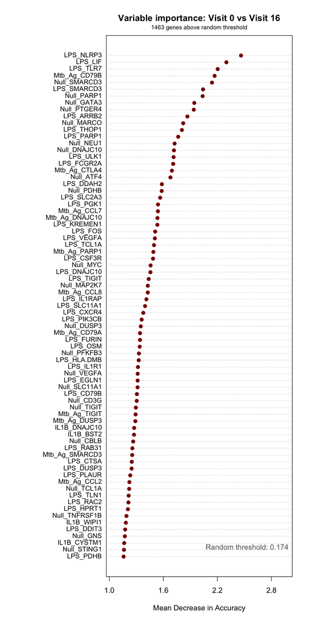

```
Saved: S4B_importance_W0_W16.png
```

```r
plot_importance_fig(
  importance_vals = avg_imp_16,
  rand_threshold  = threshold_16,
  title           = "Variable importance: Visit 0 vs Visit 16",
  save_path       = output_fig3a_s4b,
  filename        = "S4B_importance_W0_W16.png"
)
```

```r
set.seed(123)
roc_16 <- list()
for (gene in top_genes_16) {
  cat(sprintf("ROC: %s\n", gene))
  roc_16[[gene]] <- run_roc(
    data           = prep_16$data,
    gene           = gene,
    patient_id_col = rf_config$W0_W16$patient_id_col,
    n_bootstrap    = rf_config$W0_W16$n_bootstrap_roc
  )
}
```

```
ROC: LPS_NLRP3
ROC: LPS_LIF
ROC: LPS_TLR7
ROC: Mtb_Ag_CD79B
```

```r
roc_16 <- Filter(Negate(is.null), roc_16)

for (gene in names(roc_16)) {
  r <- roc_16[[gene]]
  cat(sprintf("  %-30s AUC: %.3f (95%% CI: %.3f - %.3f) | Bootstrap n: %d\n",
              gene, r$auc, r$ci_lower, r$ci_upper, r$n_valid_boot))
}
```

```
  LPS_NLRP3                      AUC: 0.943 (95% CI: 0.890 - 0.983) | Bootstrap n: 500
  LPS_LIF                        AUC: 0.912 (95% CI: 0.828 - 0.979) | Bootstrap n: 500
  LPS_TLR7                       AUC: 0.901 (95% CI: 0.797 - 0.978) | Bootstrap n: 500
  Mtb_Ag_CD79B                   AUC: 0.899 (95% CI: 0.817 - 0.980) | Bootstrap n: 500
```

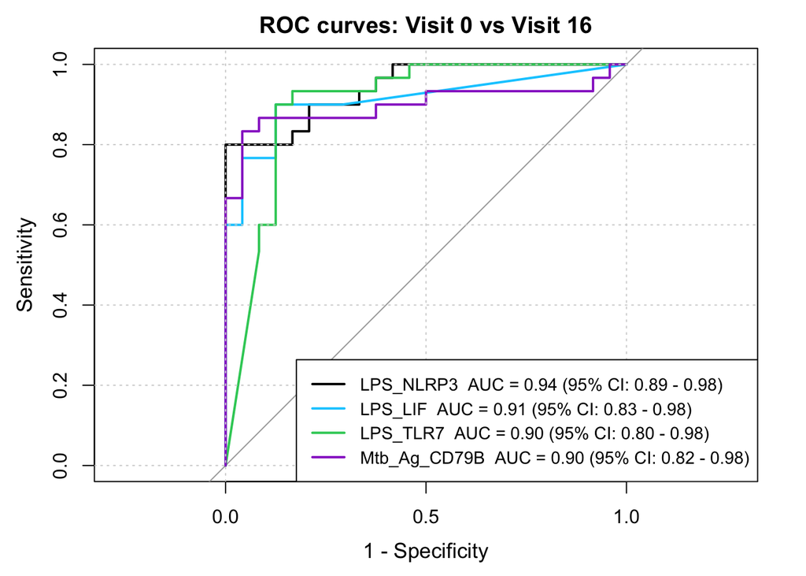

```
Saved: 3A_ROC_W0_W16.png
```

```r
plot_roc_curves(
  roc_results = roc_16,
  title       = "ROC curves: Visit 0 vs Visit 16",
  save_path   = output_fig3a_s4b,
  filename    = "3A_ROC_W0_W16.png"
)
```

```r
summary_16 <- build_summary(roc_16)
print(summary_16)
```

```
              Gene   AUC CI_Lower CI_Upper Optimal_Threshold Sensitivity_pct
2.5%     LPS_NLRP3 0.943    0.890    0.983            8.0473            80.0
2.5%1      LPS_LIF 0.912    0.828    0.979            2.1537            90.0
2.5%2     LPS_TLR7 0.901    0.797    0.978            3.2448            90.0
2.5%3 Mtb_Ag_CD79B 0.899    0.817    0.980            2.9524            83.3
      Specificity_pct PPV_pct NPV_pct Youden_J N_Bootstrap
2.5%            100.0   100.0    80.0    0.800         500
2.5%1            87.5    90.0    87.5    0.775         500
2.5%2            87.5    90.0    87.5    0.775         500
2.5%3            95.8    96.2    82.1    0.792         500
```

```r
write_xlsx(summary_16, file.path(output_fig3a_s4b, "ROC_summary_W0_W16.xlsx"))
```

# 14 Query individual genes

Use `name_map` to find the cleaned version of any gene name containing special characters, then pass the cleaned name to `query_gene`.

```r
# Find the cleaned name for a gene of interest
name_map %>% filter(grepl("NLRP3", original, ignore.case = TRUE))
```

```
      original      cleaned
1   IL1B_NLRP3   IL1B_NLRP3
2    LPS_NLRP3    LPS_NLRP3
3 Mtb_Ag_NLRP3 Mtb_Ag_NLRP3
4   Null_NLRP3   Null_NLRP3
```

```r
query_gene(
  gene_name      = "LPS_NLRP3",
  data           = prep_16$data,
  patient_id_col = "Donor",
  gene_mda       = gene_mda_16,
  rand_threshold = threshold_16
)
```

```
LPS_NLRP3
AUC: 0.943  |  95% CI: 0.890 - 0.983  |  Bootstrap n: 500
MDA: 2.462  |  Above random threshold: Yes
Optimal threshold: 8.0473  |  Sensitivity: 80.0%  |  Specificity: 100.0%
PPV: 100.0%  |  NPV: 80.0%  |  Youden J: 0.800
```